# EVCS - Consumption Prediction of UK by Time Series

### In this analysis, we would like to develop a prediction model based on time series data generated from the EVCS dataset in the UK and forecast future energy consumption trends for the next 365 days.

```python
import pandas as pd
import numpy as np
import scipy.stats
import matplotlib.pyplot as plt
import matplotlib.ticker as ticker
import datetime
from datetime import datetime as dt
import warnings
import seaborn as sns
warnings.filterwarnings("ignore")
```

```python
# Concat datasets for 2017, 2018 and 2019
df1 = pd.read_csv("/Users/merry/Documents/Deakin - Master of Data Science/T1 2022/SIT764/Capstone/EV Adoption Tools/Datasets/UK_Perth and Kinross_EVCS Usage/EVCS Usage_Sep16_Aug17_PerthandKinross.csv")
df2 = pd.read_csv("/Users/merry/Documents/Deakin - Master of Data Science/T1 2022/SIT764/Capstone/EV Adoption Tools/Datasets/UK_Perth and Kinross_EVCS Usage/EVCS Usgae_Sep17_Aug18_PerthandKinross.csv")
df3 = pd.read_csv("/Users/merry/Documents/Deakin - Master of Data Science/T1 2022/SIT764/Capstone/EV Adoption Tools/Datasets/UK_Perth and Kinross_EVCS Usage/EVCS Usage_Sep18_Aug19_PerthandKinross.csv")
df = pd.concat([df1,df2,df3],axis=0,ignore_index=True)
df.head()
```

|  | _id | CP ID | Connector | Start Date | Start Time | End Date | End Time | Total kWh | Site | Model |
| --- | --- | --- | --- | --- | --- | --- | --- | --- | --- | --- |
| 0 | 1 | 51519 | 2 | 2017-08-31T00:00:00 | 22:12 | 2017-08-31T00:00:00 | 23:11 | 18.27 | Broxden Park & Ride, Perth | APT Triple Rapid Charger |
| 1 | 2 | 51250 | 1 | 2017-08-31T00:00:00 | 22:01 | 2017-08-31T00:00:00 | 22:31 | 19.45 | Crown Inn Wynd Car Park, Auchterarder | Siemens Triple Rapid Charger |
| 2 | 3 | 50575 | 2 | 2017-08-31T00:00:00 | 21:21 | 2017-08-31T00:00:00 | 21:59 | 19.71 | South Inch Car Park, Perth | APT Triple Rapid Charger |
| 3 | 4 | 51516 | 2 | 2017-08-31T00:00:00 | 20:43 | 2017-08-31T00:00:00 | 21:03 | 9.84 | Kinross Park and Ride | APT Triple Rapid Charger |
| 4 | 5 | 50994 | 2 | 2017-08-31T00:00:00 | 19:50 | 2017-08-31T00:00:00 | 20:50 | 14.17 | Leslie Street Car Park, Blairgowrie | APT Triple Rapid Charger |

### Data Cleaning

```python
df.isnull().sum()
```

```
_id             0
CP ID           0
Connector       0
Start Date      0
Start Time      0
End Date      185
End Time      185
Total kWh     185
Site            0
Model           0
dtype: int64
```

```python
# Remove null values and get information of each variables
df = df.dropna()
df.info()
```

```
<class 'pandas.core.frame.DataFrame'>
Int64Index: 66479 entries, 0 to 66663
Data columns (total 10 columns):
 #   Column      Non-Null Count  Dtype
---  ------      --------------  -----
 0   _id         66479 non-null  int64
 1   CP ID       66479 non-null  int64
 2   Connector   66479 non-null  int64
 3   Start Date  66479 non-null  object
 4   Start Time  66479 non-null  object
 5   End Date    66479 non-null  object
 6   End Time    66479 non-null  object
 7   Total kWh   66479 non-null  float64
 8   Site        66479 non-null  object
 9   Model       66479 non-null  object
dtypes: float64(1), int64(3), object(6)
memory usage: 5.6+ MB
```

```python
# Sort values by "Start Date"
df = df.sort_values(by = ["Start Date"])
df["Start Date"] = pd.to_datetime(df["Start Date"]).dt.date
df["End Date"] = pd.to_datetime(df["End Date"]).dt.date
df["Start"] = pd.to_datetime(df["Start Time"])
df["End"] = pd.to_datetime(df["End Time"])
df["Start mins"] = df["Start"].dt.hour*60 + df["Start"].dt.minute
df["End mins"] = df["End"].dt.hour*60 + df["End"].dt.minute
df["Time Period"] = df["End mins"] - df["Start mins"]
df = df[["Connector", "Start Date", "Start Time", "End Date", "End Time", "Time Period", "Total kWh", "Site", "Model"]]
```

```python
# Calibrate time period since some transactions were across midnight
for i in range(len(df)):
    if df["Time Period"].iloc[i] < 0:
        df["Time Period"].iloc[i] += 1440
df["Time Period"].describe()
```

```
count    66479.000000
mean        79.671987
std        148.393328
min          0.000000
25%         18.000000
50%         31.000000
75%         60.000000
max       1437.000000
Name: Time Period, dtype: float64
```

```python
for i in range(len(df)):
    if df["Total kWh"].iloc[i] < 0:
        df["Total kWh"].iloc[i] = 0
df["Total kWh"].describe()
```

```
count    66479.000000
mean        10.779256
std          8.741784
min          0.000000
25%          5.040000
50%          8.720000
75%         14.840000
max        287.710000
Name: Total kWh, dtype: float64
```

```python
# Final dataset
df.head()
```

|  | Connector | Start Date | Start Time | End Date | End Time | Time Period | Total kWh | Site | Model |
| --- | --- | --- | --- | --- | --- | --- | --- | --- | --- |
| 13674 | 2 | 2016-01-09 | 07:51 | 2016-01-09 | 09:01 | 70 | 3.87 | Rie-Achan Road Car Park, Pitlochry | APT 22kW Dual Outlet |
| 13673 | 1 | 2016-01-09 | 08:22 | 2016-01-09 | 14:32 | 370 | 13.93 | Broxden Park & Ride | APT 22kW Dual Outlet |
| 13672 | 1 | 2016-01-09 | 08:54 | 2016-01-09 | 16:37 | 463 | 10.38 | Rie-Achan Road Car Park, Pitlochry | APT 22kW Dual Outlet |
| 13671 | 2 | 2016-01-09 | 09:22 | 2016-01-09 | 09:37 | 15 | 3.58 | Kinross Park and Ride | APT Triple Rapid Charger |
| 13670 | 2 | 2016-01-09 | 10:06 | 2016-01-09 | 12:01 | 115 | 5.96 | Rie-Achan Road Car Park, Pitlochry | APT 22kW Dual Outlet |

### Data Exploration

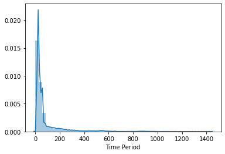

```python
# Exploration on charge time period as one of the research task
sns.distplot(df["Time Period"])
```

```python
df["Time Period"].describe()
```

```
count    66479.000000
mean        79.671987
std        148.393328
min          0.000000
25%         18.000000
50%         31.000000
75%         60.000000
max       1437.000000
Name: Time Period, dtype: float64
```

#### Fit Weibull Distribution

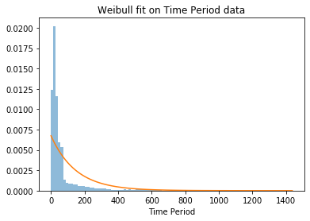

```python
# Weibull Distribution
from scipy.stats import weibull_min
plt.hist(df["Time Period"], bins=100, density=True, alpha=0.5)
shape, loc, scale = weibull_min.fit(df["Time Period"], floc=0)
x = np.linspace(df["Time Period"].min(), df["Time Period"].max(), 100)
plt.plot(x, weibull_min(shape, loc, scale).pdf(x))
plt.title("Weibull fit on Time Period data")
plt.xlabel("Time Period")
```

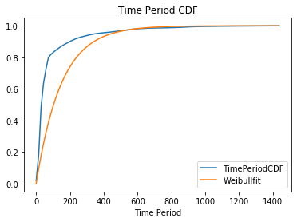

```python
# CDF for Weibull Distribution
import statsmodels.distributions
ecdf=statsmodels.distributions.ECDF(df["Time Period"])
plt.plot(x,ecdf(x),label="TimePeriodCDF")
plt.plot(x,weibull_min(shape,loc,scale).cdf(x), label="Weibullfit")
plt.title("Time Period CDF")
plt.xlabel("Time Period")
plt.legend()
```

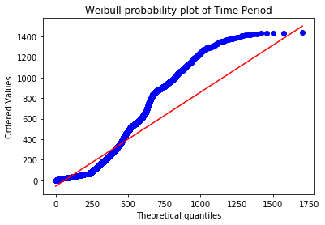

```python
# Probility plot of Weibull
from scipy.stats import probplot, weibull_min
probplot(df["Time Period"], dist=weibull_min(shape,loc,scale), plot=plt.figure().add_subplot(111))
plt.title("Weibull probability plot of Time Period")
```

#### Fit Lognormal Distribution

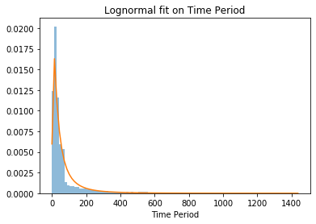

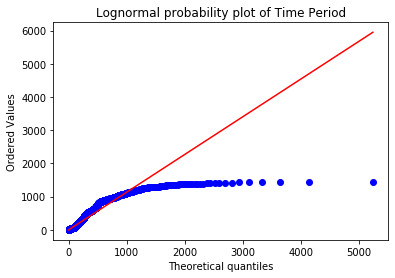

```python
# Lognormal Distribution
shape,loc,scale=scipy.stats.lognorm.fit(df["Time Period"])
fitted=scipy.stats.lognorm(shape,loc,scale)
plt.hist(df["Time Period"],bins=100,density=True,alpha=0.5)
x=np.linspace(df["Time Period"].min(),df["Time Period"].max(),100)
plt.plot(x,fitted.pdf(x))
plt.title("Lognormal fit on Time Period")
plt.xlabel("Time Period")
scipy.stats.probplot(df["Time Period"],dist=fitted, plot=plt.figure().add_subplot(111))
plt.title("Lognormal probability plot of Time Period")
```

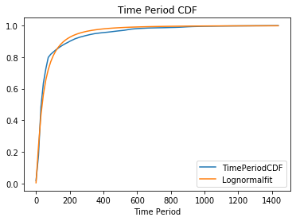

```python
# CDF for Lognormal Distribution
ecdf=statsmodels.distributions.ECDF(df["Time Period"])
plt.plot(x,ecdf(x),label="TimePeriodCDF")
plt.plot(x,scipy.stats.lognorm(shape,loc,scale).cdf(x), label="Lognormalfit")
plt.title("Time Period CDF")
plt.xlabel("Time Period")
plt.legend()
```

```python
# Percent-Point Function
scipy.stats.lognorm(shape,loc,scale).ppf(0.8)
```

```
97.93142337883845
```

##### As we fit the Time Period variable with both Weibull and Lognormal distribution, the percent point function suggest that 80% of charging event were equal or under 97.93 minutes. Compared with the result we generated from Netherland, average charging time in Perth and Kinross Region in the UK is much shorter than that of Netherland.

## Time Series Prediction

#### Time Series Pattern

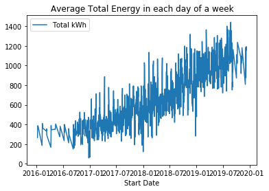

```python
# Investigate the total energy pattern in each day of a week
grouped_df_day = df["Total kWh"].groupby(df["Start Date"]).sum()
te_day = pd.DataFrame({"Start Date": grouped_df_day.index, "Total kWh":grouped_df_day.values})
ax = te_day.set_index("Start Date").plot(kind="line")
ax.set_title("Average Total Energy in each day of a week")
```

```python
grouped_df_day.describe()
```

```
count    1095.000000
mean      654.423919
std       277.264863
min        59.550000
25%       423.087500
50%       607.640000
75%       881.402000
max      1441.057000
Name: Total kWh, dtype: float64
```

##### Total energy consumption (grouped by each day) is increasing over time. In this case, we can formulate a new dataset for time series forecasting. Average daily energy consumption is around 654.42 kWh, which lies in the range of 59.55 kWh to 1441.06 kWh per day.

### Prediction Model

```python
import fbprophet
from fbprophet import Prophet
data = pd.DataFrame(grouped_df_day)
data = data.reset_index(level=0)
data.columns = ["ds", "y"]
data["y"] = (data["y"] - data["y"].min()) / (data["y"].max() - data["y"].min())
data.head()
```

|  | ds | y |
| --- | --- | --- |
| 0 | 2016-01-09 | 0.150337 |
| 1 | 2016-01-10 | 0.227912 |
| 2 | 2016-01-11 | 0.235793 |
| 3 | 2016-01-12 | 0.237836 |
| 4 | 2016-02-09 | 0.091743 |

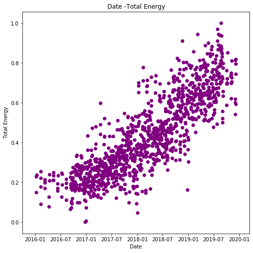

```python
# Plot Time Series Data
fig, ax = plt.subplots(figsize=(8, 8))

# Add x-axis and y-axis
ax.scatter(data['ds'],
           data['y'],
           color='purple')

# Set title and labels for axes
ax.set(xlabel='Date',
       ylabel='Total Energy',
       title="Date -Total Energy")

plt.show()
```

```python
# Initialise the Time Series Model
model = Prophet()
```

```python
model.fit(data)
```

```
INFO:fbprophet:Disabling daily seasonality. Run prophet with daily_seasonality=True to override this.
```

```
<fbprophet.forecaster.Prophet at 0x7f7a15e6f410>
```

```python
# Create future dates
future_dates = model.make_future_dataframe(periods = 365)
```

```python
# Make prediction
prediction = model.predict(future_dates)
prediction.head()
```

|  | ds | trend | yhat_lower | yhat_upper | trend_lower | trend_upper | additive_terms | additive_terms_lower | additive_terms_upper | weekly | weekly_lower | weekly_upper | yearly | yearly_lower | yearly_upper | multiplicative_terms | multiplicative_terms_lower | multiplicative_terms_upper | yhat |
| --- | --- | --- | --- | --- | --- | --- | --- | --- | --- | --- | --- | --- | --- | --- | --- | --- | --- | --- | --- |
| 0 | 2016-01-09 | 0.126916 | -0.001126 | 0.263226 | 0.126916 | 0.126916 | 0.002966 | 0.002966 | 0.002966 | -0.018400 | -0.018400 | -0.018400 | 0.021366 | 0.021366 | 0.021366 | 0.0 | 0.0 | 0.0 | 0.129882 |
| 1 | 2016-01-10 | 0.127194 | -0.004503 | 0.249940 | 0.127194 | 0.127194 | -0.006674 | -0.006674 | -0.006674 | -0.030317 | -0.030317 | -0.030317 | 0.023643 | 0.023643 | 0.023643 | 0.0 | 0.0 | 0.0 | 0.120520 |
| 2 | 2016-01-11 | 0.127471 | 0.037185 | 0.297848 | 0.127471 | 0.127471 | 0.040298 | 0.040298 | 0.040298 | 0.015078 | 0.015078 | 0.015078 | 0.025220 | 0.025220 | 0.025220 | 0.0 | 0.0 | 0.0 | 0.167769 |
| 3 | 2016-01-12 | 0.127749 | 0.017792 | 0.266053 | 0.127749 | 0.127749 | 0.017050 | 0.017050 | 0.017050 | -0.009066 | -0.009066 | -0.009066 | 0.026115 | 0.026115 | 0.026115 | 0.0 | 0.0 | 0.0 | 0.144799 |
| 4 | 2016-02-09 | 0.135523 | 0.001797 | 0.258041 | 0.135523 | 0.135523 | -0.003080 | -0.003080 | -0.003080 | -0.009066 | -0.009066 | -0.009066 | 0.005985 | 0.005985 | 0.005985 | 0.0 | 0.0 | 0.0 | 0.132443 |

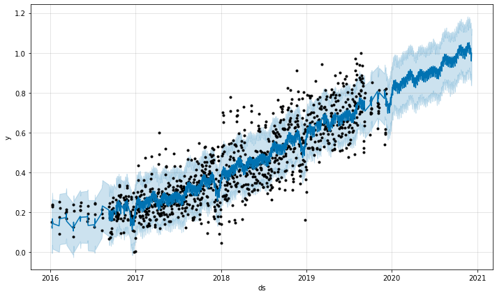

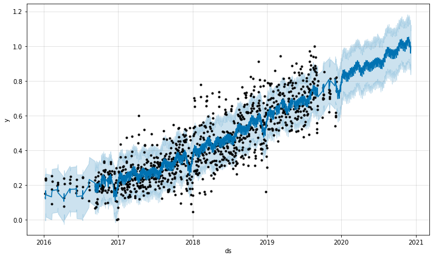

```python
model.plot(prediction)
```

##### Our future prediction on the total energy consumption still suggests an upward trend in the next one year (which is 2020 since we could only get access to 2019 dataset at the moment. Further investigation would be conducted based on the most updated datasets).

```python
# Cross Validation
from fbprophet.diagnostics import cross_validation
data_cv = cross_validation(model, initial = "730 days", period = "180 days", horizon = "365 days")
data_cv.head()
```

```
INFO:fbprophet:Making 2 forecasts with cutoffs between 2018-06-11 00:00:00 and 2018-12-08 00:00:00
```

|  | ds | yhat | yhat_lower | yhat_upper | y | cutoff |
| --- | --- | --- | --- | --- | --- | --- |
| 0 | 2018-06-12 | 0.453178 | 0.333847 | 0.567816 | 0.695633 | 2018-06-11 |
| 1 | 2018-06-13 | 0.453245 | 0.339796 | 0.578500 | 0.396733 | 2018-06-11 |
| 2 | 2018-06-14 | 0.467487 | 0.353040 | 0.585444 | 0.347518 | 2018-06-11 |
| 3 | 2018-06-15 | 0.468388 | 0.353930 | 0.584769 | 0.606968 | 2018-06-11 |
| 4 | 2018-06-16 | 0.449124 | 0.330589 | 0.569030 | 0.482603 | 2018-06-11 |

```python
from fbprophet.diagnostics import performance_metrics
data_p = performance_metrics(data_cv)
data_p
```

|  | horizon | mse | rmse | mae | mape | coverage |
| --- | --- | --- | --- | --- | --- | --- |
| 0 | 30 days | 0.015454 | 0.124313 | 0.093208 | 0.207015 | 0.716667 |
| 1 | 31 days | 0.015115 | 0.122943 | 0.092469 | 0.205793 | 0.716667 |
| 2 | 32 days | 0.015182 | 0.123216 | 0.093081 | 0.207572 | 0.716667 |
| 3 | 33 days | 0.015203 | 0.123299 | 0.093342 | 0.208450 | 0.716667 |
| 4 | 34 days | 0.015158 | 0.123117 | 0.093441 | 0.208743 | 0.725000 |
| ... | ... | ... | ... | ... | ... | ... |
| 324 | 361 days | 0.015164 | 0.123141 | 0.097581 | 0.136768 | 0.666667 |
| 325 | 362 days | 0.014039 | 0.118487 | 0.093922 | 0.133686 | 0.683333 |
| 326 | 363 days | 0.013679 | 0.116957 | 0.091597 | 0.130522 | 0.700000 |
| 327 | 364 days | 0.013600 | 0.116618 | 0.091265 | 0.129652 | 0.716667 |
| 328 | 365 days | 0.013754 | 0.117278 | 0.092315 | 0.130485 | 0.716667 |

329 rows × 6 columns

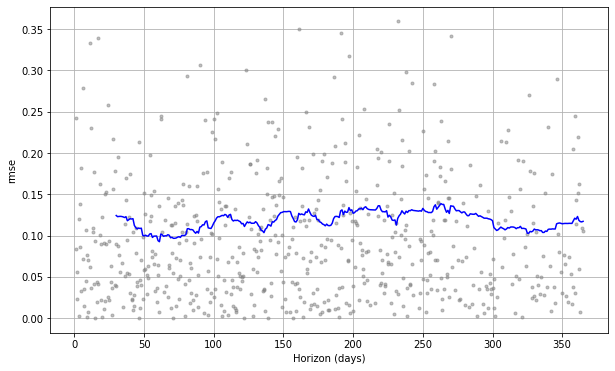

```python
from fbprophet.plot import plot_cross_validation_metric
fig = plot_cross_validation_metric(data_cv, metric = "rmse")
```

##### Our time-series model suggests an upward trend of total energy consumption over time. Future work would include feeding the most updated datasets into our time-series model and making predictions for the coming year. Such a process would enable us or our future clients to estimate the total energy consumption in a period of time that can satisfy all EV user demands on their networks. Another research point would be how we judge on total energy consumption in one EVCS would reach a threshold that requires for creation of another EVCS in the same region.